# M2 Visualisation d’informations sur R

# Découper la fenêtre graphique

### grid.arrange() du package gridExtra

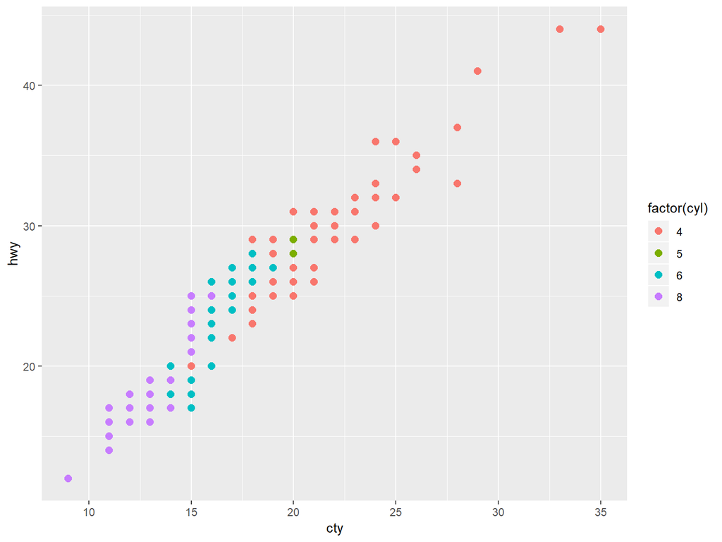

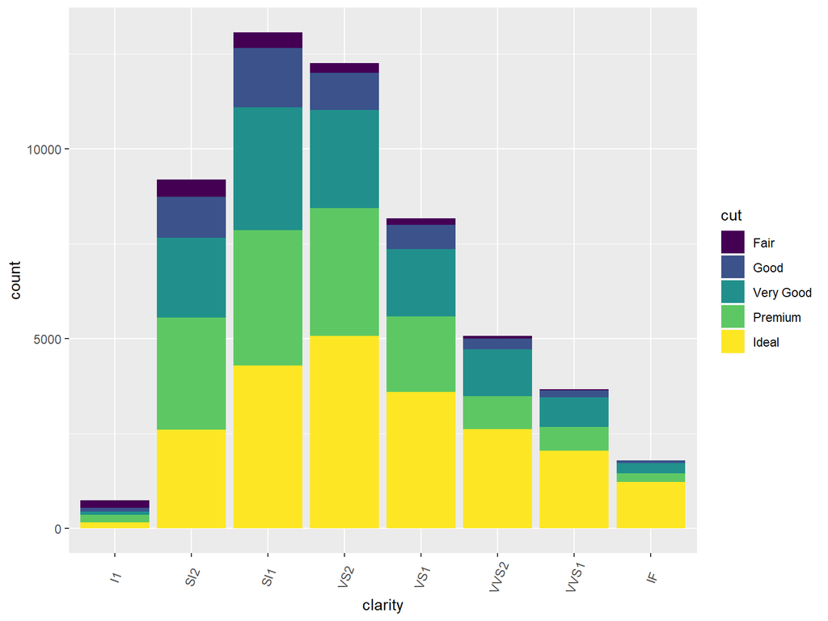

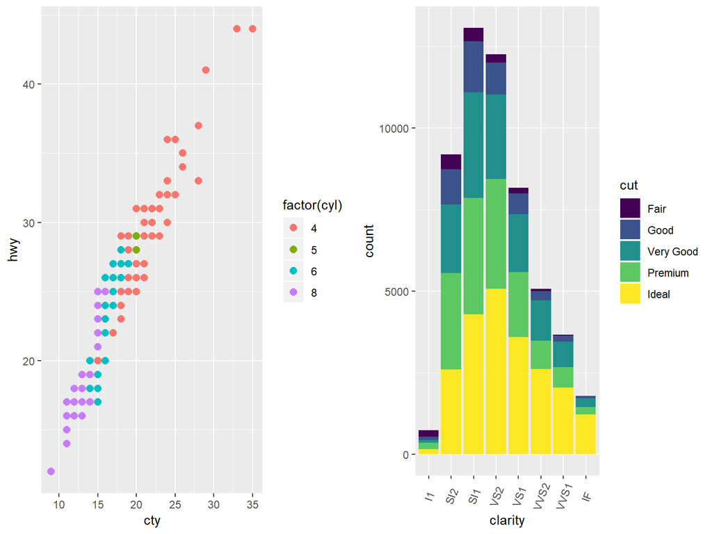

```r
library(gridExtra)
# Nuage de points
data(mpg)
sp <- ggplot(mpg, aes(x = cty, y = hwy, colour = factor(cyl)))+
  geom_point(size=2.5)

sp
# Bar plot
bp <- ggplot(diamonds, aes(clarity, fill = cut)) +
  geom_bar() +
  theme(axis.text.x = element_text(angle=70, vjust=0.5))
bp

grid.arrange(sp,bp,ncol=2,nrow=1)
```

### ggdraw() du package cowplot

La fonction draw_plot() peut être utilisée pour placer des graphiques dans des sites spécifiques avec une taille particulière. Le format de la fonction est la suivante:

draw_plot(plot, x = 0, y = 0, width = 1, height = 1)

plot: Le graphique à placer (ggplot2 ou un gtable) x: L’abscisse x du coin inférieur gauche du graphique y: L’ordonnée y du coin inférieur gauche du graphique width, height: la largeur et la hauteur du graphique

La fonction ggdraw() est utilisée pour initialiser le graphique.

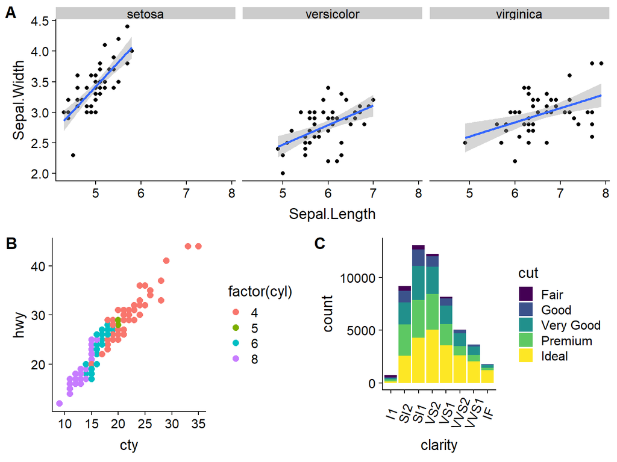

```r
library(cowplot)
data(iris)
plot.iris <- ggplot(iris, aes(Sepal.Length, Sepal.Width)) +
  geom_point() + facet_grid(. ~ Species) +
  stat_smooth(method = "lm")

ggdraw() +
  draw_plot(plot.iris, 0, .5, 1, .5) +
  draw_plot(sp, 0, 0, .5, .5) +
  draw_plot(bp, .5, 0, .5, .5) +
  draw_plot_label(c("A", "B", "C"), c(0, 0, 0.5), c(1, 0.5, 0.5), size = 15)
```

# Sauver un graphique avec la fonction ggsave()

```r
ggsave("ggdraw.pdf", width = 20, height = 20, units = "cm")
```

# Diagramme en barre: position

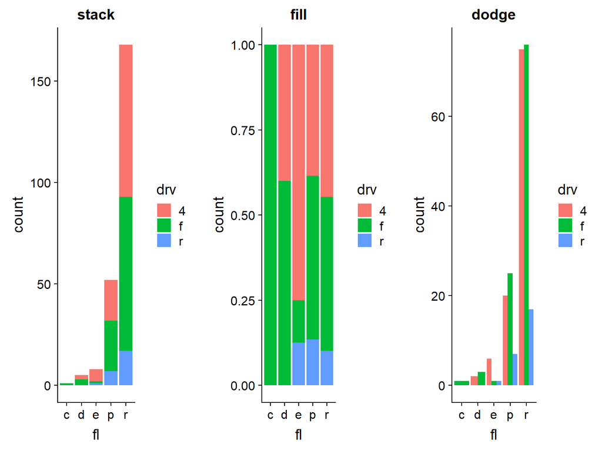

```r
g1<-ggplot(data = mpg) +
  geom_bar(aes(x = fl, fill=drv),position="stack")+
  labs(title="stack")

g2<-ggplot(data = mpg) +
  geom_bar(aes(x = fl, fill=drv),position="fill")+
  labs(title="fill")

g3<-ggplot(data = mpg) +
  geom_bar(aes(x = fl, fill=drv),position="dodge")+
  labs(title="dodge")

grid.arrange(g1, g2, g3,ncol = 3, nrow = 1)
```

# Cas particulier du graphe sectoriel

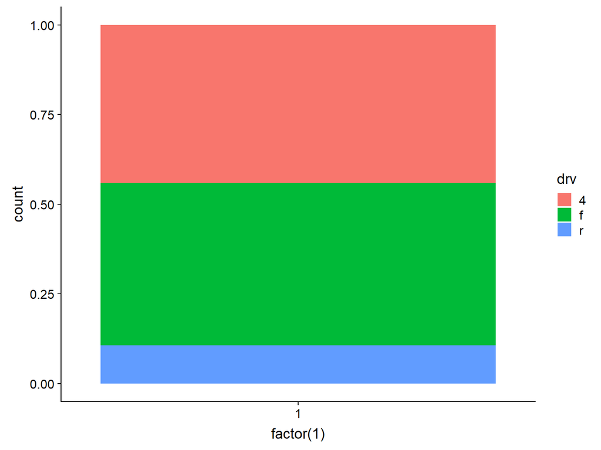

```r
# Etape 1: Histogramme
hist<- ggplot(data = mpg) +
  geom_bar(aes(x = factor(1), fill=drv),position="fill", width = 1)
hist
```

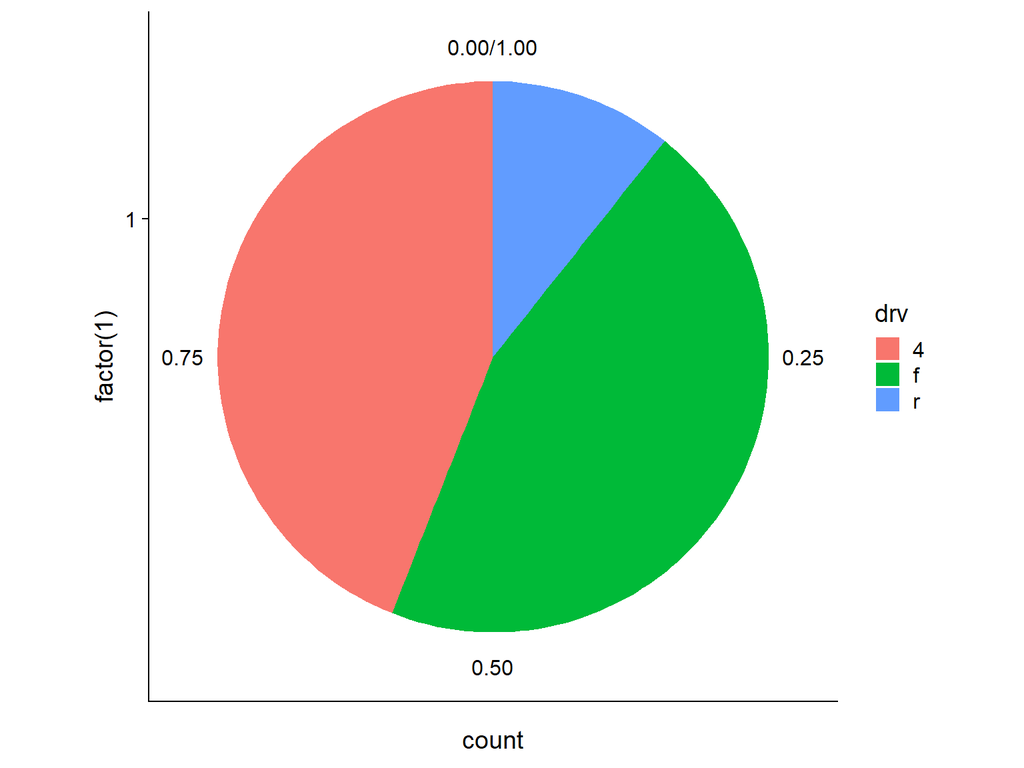

```r
# Etape 2: On transforme l'histogramme en camembert
camembert <- hist + coord_polar("y")
camembert
```

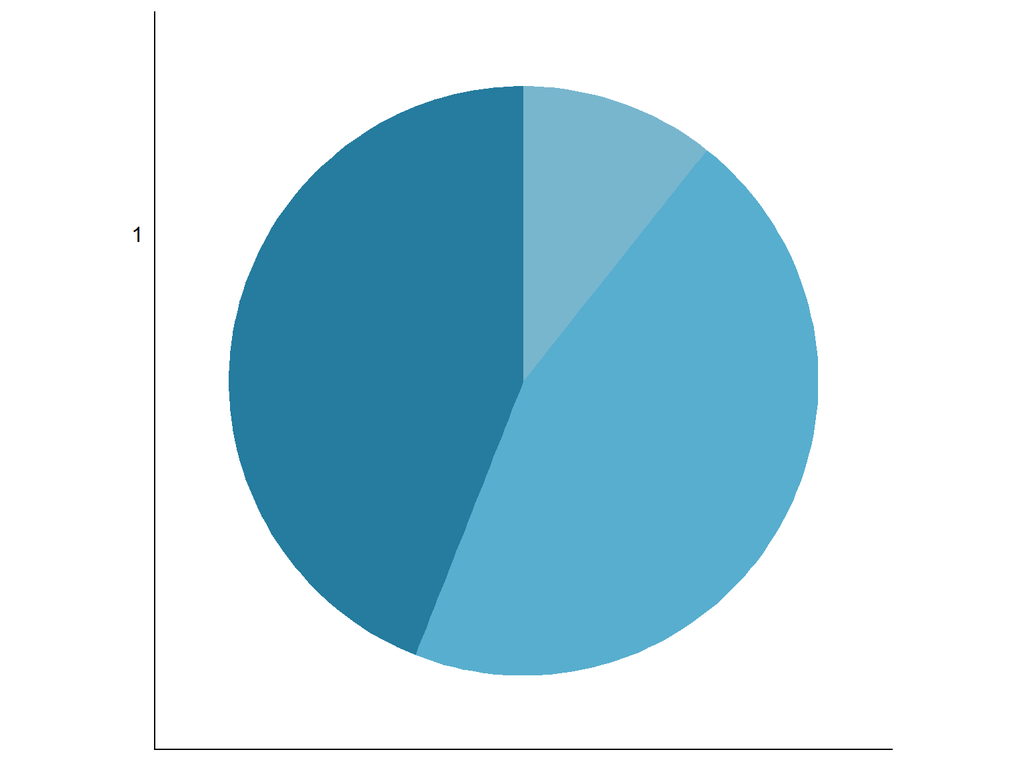

```r
# Etape 3: On met en forme notre camembert

camembert_propre <- camembert + scale_fill_manual(values=c("#257C9E", "#58AECE","#78B6CE")) +
  theme(
    axis.text.x=element_blank(),
    axis.title.x = element_blank(),
    axis.title.y = element_blank(),
    panel.border = element_blank(),
    panel.grid=element_blank(),
    axis.ticks = element_blank(),
    plot.title=element_text(size=14, face="bold",hjust = 0.5, color='#797979'),# taille du titre, caractère gras et centrage du titre
    legend.position="none"
  )
camembert_propre
```

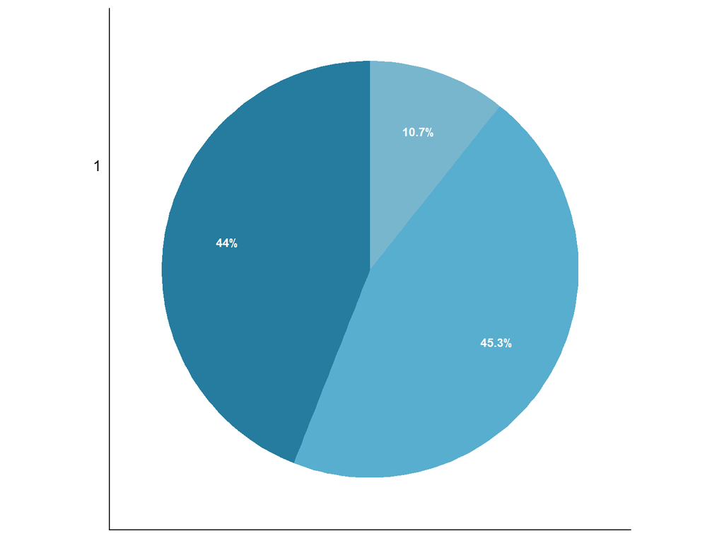

```r
# Etape 4: On met des étiquettes

Lab<-mpg%>%
  group_by(drv)%>%
  summarise (n = n())%>%
  mutate(freq = n / sum(n),
         rsomcum=rev(cumsum(rev(freq))),
         milieu=rsomcum-freq/2,
         labels=paste0(round(freq*100,1), '%'))

camembert_propre+
geom_text(data=Lab,aes(x=1.2, y=milieu,label=labels),
          color="#FFFFFF",
          fontface="bold",
          size=3.3
)
```

# Annoter les graphiques

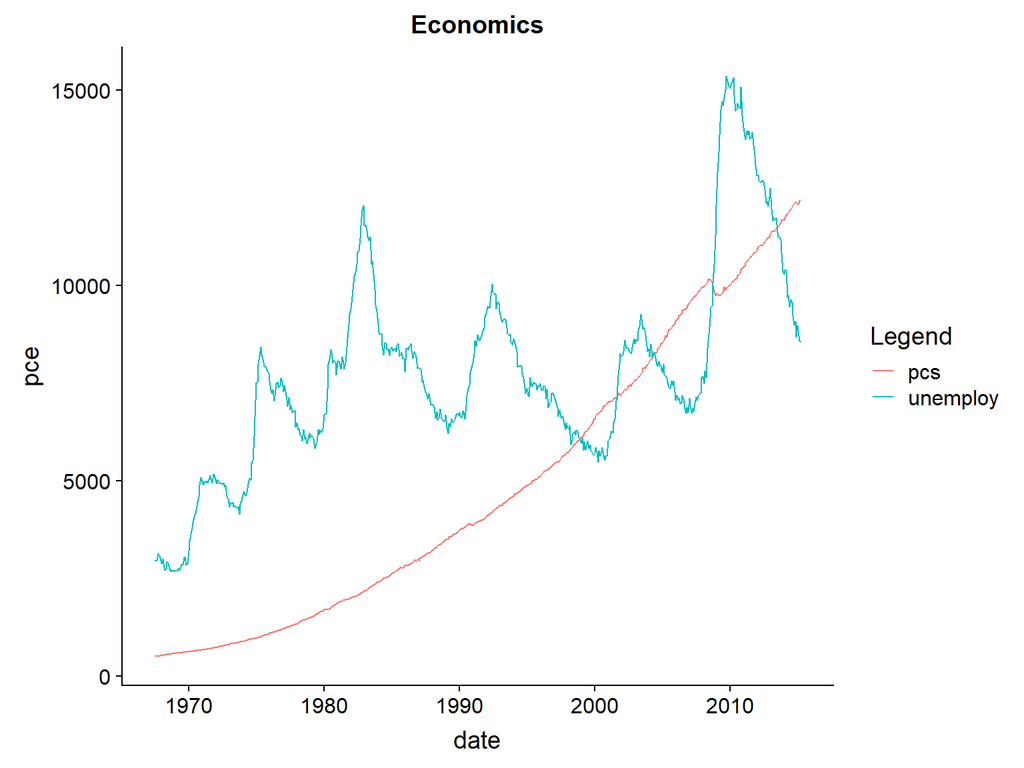

```r
#Serie temporelle
data(economics, package="ggplot2")  # init data
economics <- data.frame(economics)  # convert to dataframe
p<-ggplot(economics) +
  geom_line(aes(x=date, y=pce, color="pcs")) +
  geom_line(aes(x=date, y=unemploy, col="unemploy")) +
  scale_color_discrete(name="Legend") +
  labs(title="Economics")
p
```

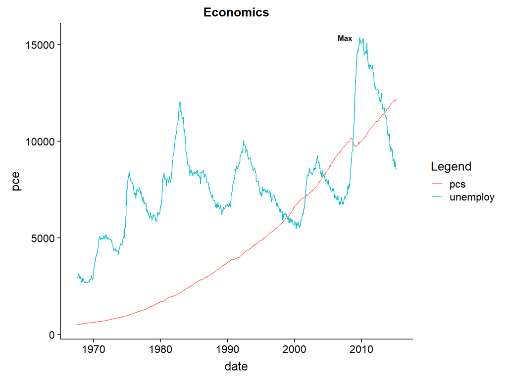

```r
#Ajouter du texte sur une position spécifique
p + annotate("text", x = economics$date[which.max(economics$unemploy)], y = economics$unemploy[which.max(economics$unemploy)], label ="Max" , size=3 , angle=0, fontface="bold",hjust = 1.5)
```

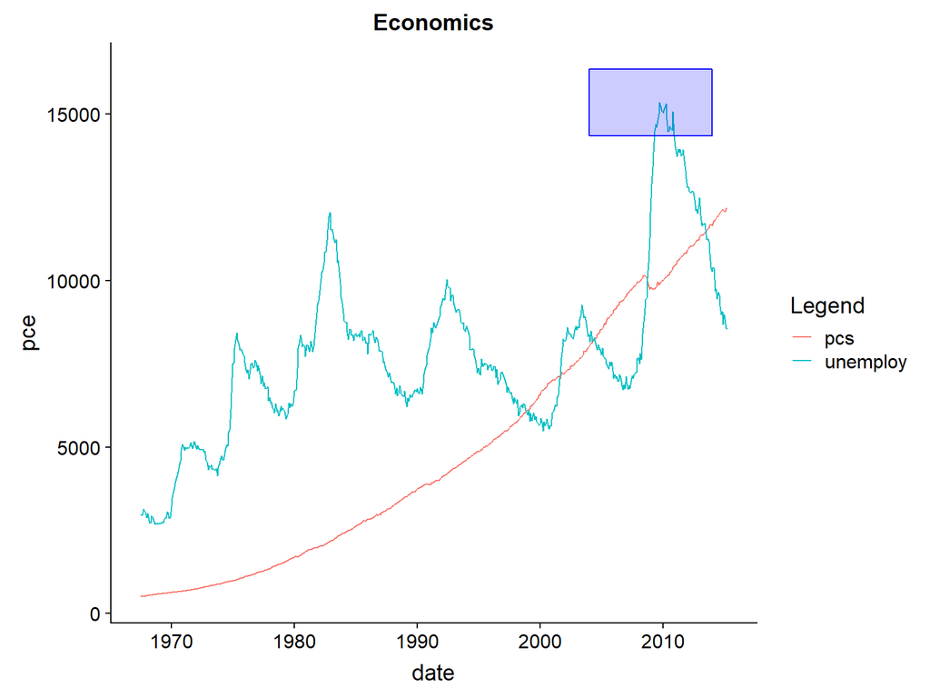

```r
# Ajouter un rectangle
library("lubridate")
x1<-floor_date(economics$date[which.max(economics$unemploy)]-(365*5), unit = "year")
x2<-floor_date(economics$date[which.max(economics$unemploy)]+(365*5), unit = "year")-1
y1<-economics$unemploy[which.max(economics$unemploy)]-1000
y2<-economics$unemploy[which.max(economics$unemploy)]+1000
p + annotate("rect", xmin=x1, xmax=x2, ymin=y1 , ymax=y2, alpha=0.2, color="blue", fill="blue")
```

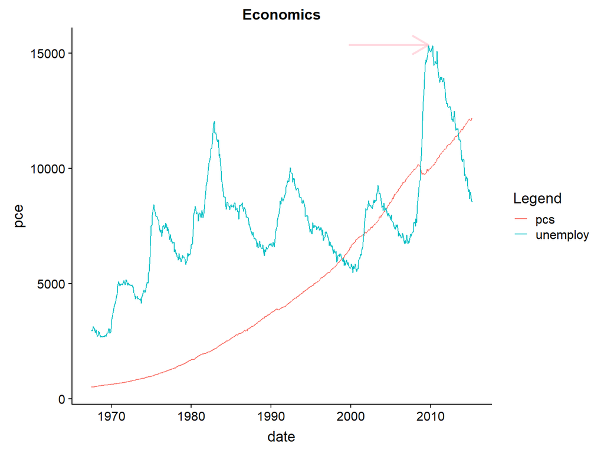

```r
# Ajouter une flêche
p + annotate("segment", x = economics$date[which.max(economics$unemploy)]-(365*10),
             xend = economics$date[which.max(economics$unemploy)],
             y = max(economics$unemploy),
             yend = max(economics$unemploy),
             colour = "pink", size=1, alpha=0.6, arrow=arrow())
```